# ORF9b protein / Protein 9b

Fold-switch pair **7kdtB_6z4uA** — **7kdtB** vs **6z4uA**

Severe acute respiratory syndrome coronavirus 2

## Figure 1: Phylogenetic tree with per-cluster fold-preference heatmap.

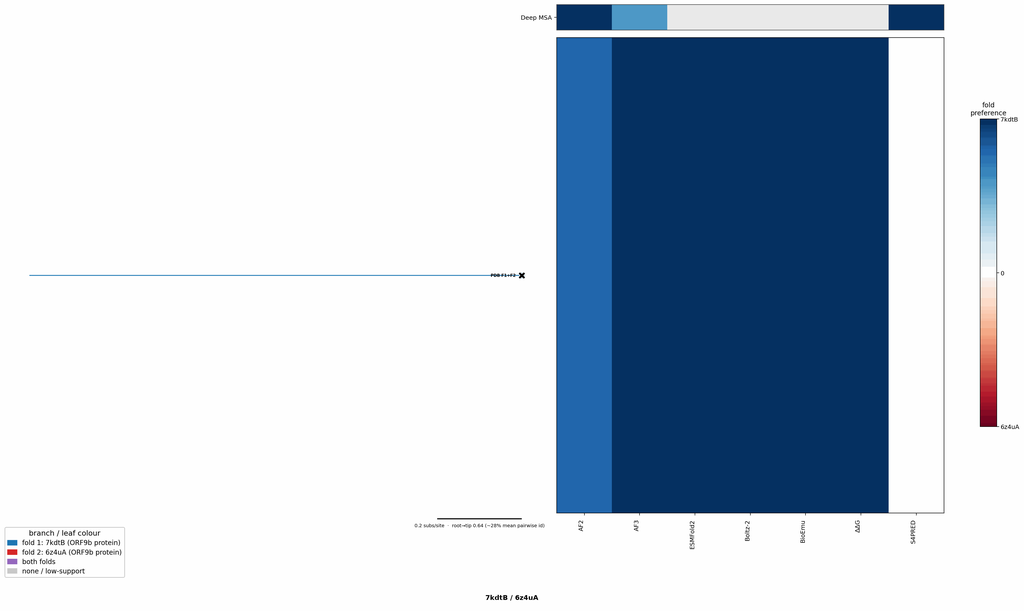

## Figure 2: Aligned overlay (both folds superposed)

The single fold-switching chain of each fold superposed by TM-align; waters hidden, any ligand shown as green sticks. Grey = structurally conserved core, colour = divergent (fold-switching) region.

7kdtB (ORF9b protein / Protein 9b) · dimer6z4uA (ORF9b protein / Protein 9b) · monomerLigand 15P (bound to 6z4uA)

TM-score: 0.051 · Trigger class: protein_binding

Aligned overlay

## Figure 3: The two folds, side by side

Each fold is coloured by per-residue Cα deviation between the two superposed structures: grey ≈ conserved core, full colour = structurally divergent (fold-switching) region.

7kdtB (ORF9b protein / Protein 9b)

6z4uA (ORF9b protein / Protein 9b)

0 Å5≥10 Å

7kdtB (ORF9b protein / Protein 9b)

6z4uA (ORF9b protein / Protein 9b)

## Figure 4: Best-cluster predicted contact maps over the two true folds.

Predicted contact maps (MSA-Transformer) for the clusters best matching each fold, over the true contacts of fold 1 (upper triangle) and fold 2 (lower). Divergent contacts between clusters are the contact-level signature of fold-switching.

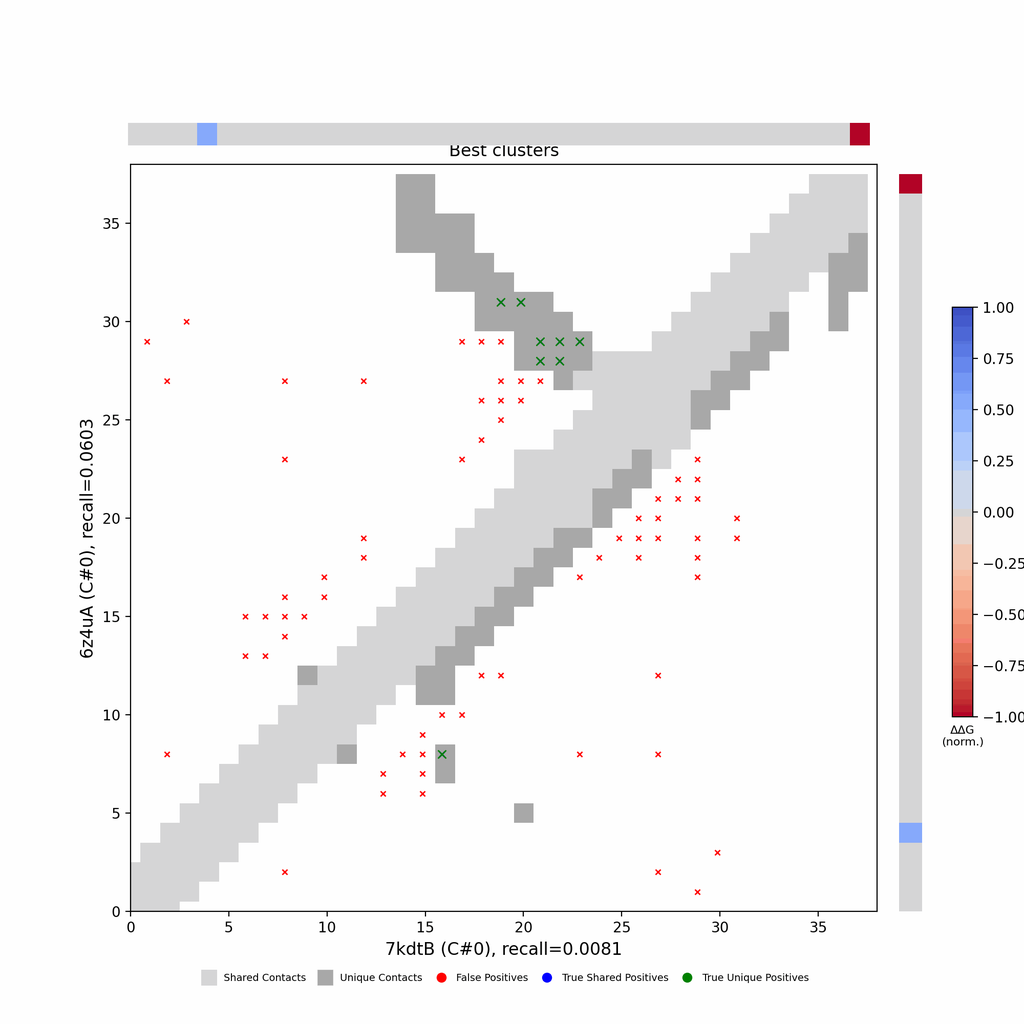

## Figure 5: Per-residue ΔΔG fold-preference contribution

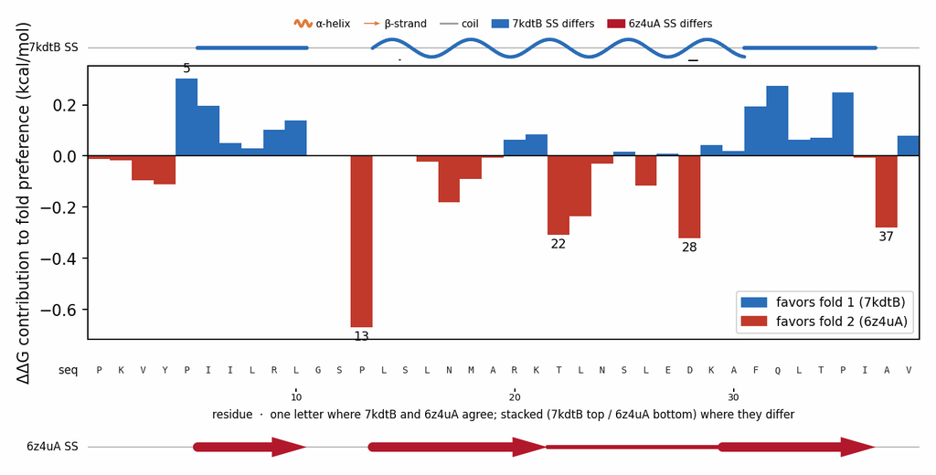

**More figures**

## Figure 6: Deep-MSA contact map panel / Best clusters contact map panel

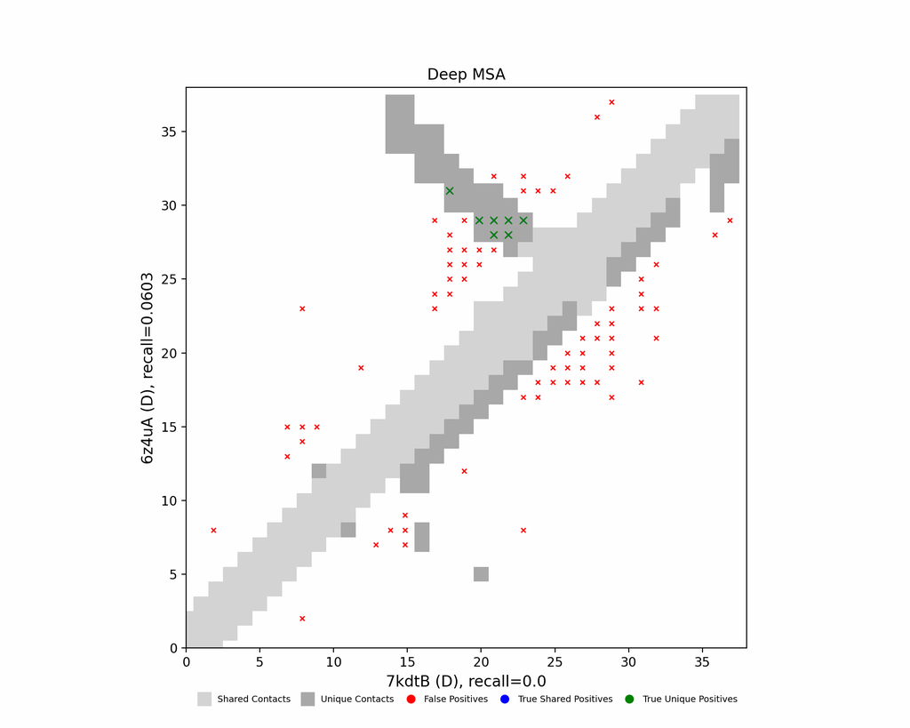

Deep-MSA contact map panel

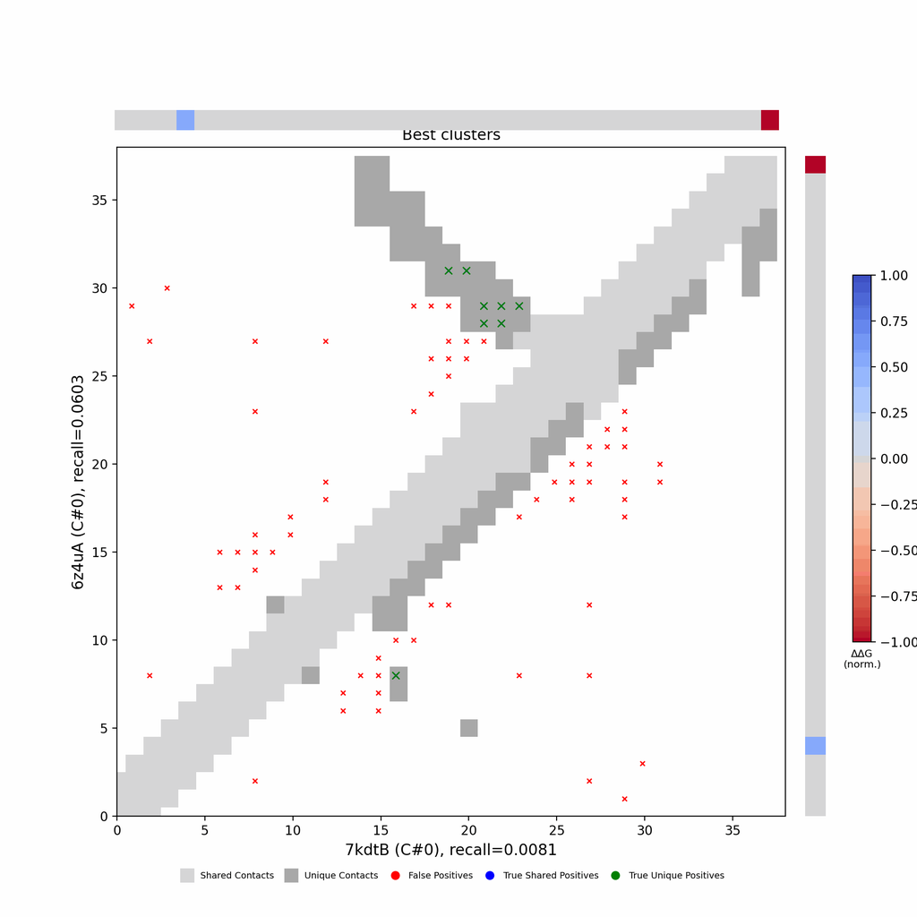

Best clusters contact map panel

## Figure 7: All clusters contact-map mosaic (small multiples).

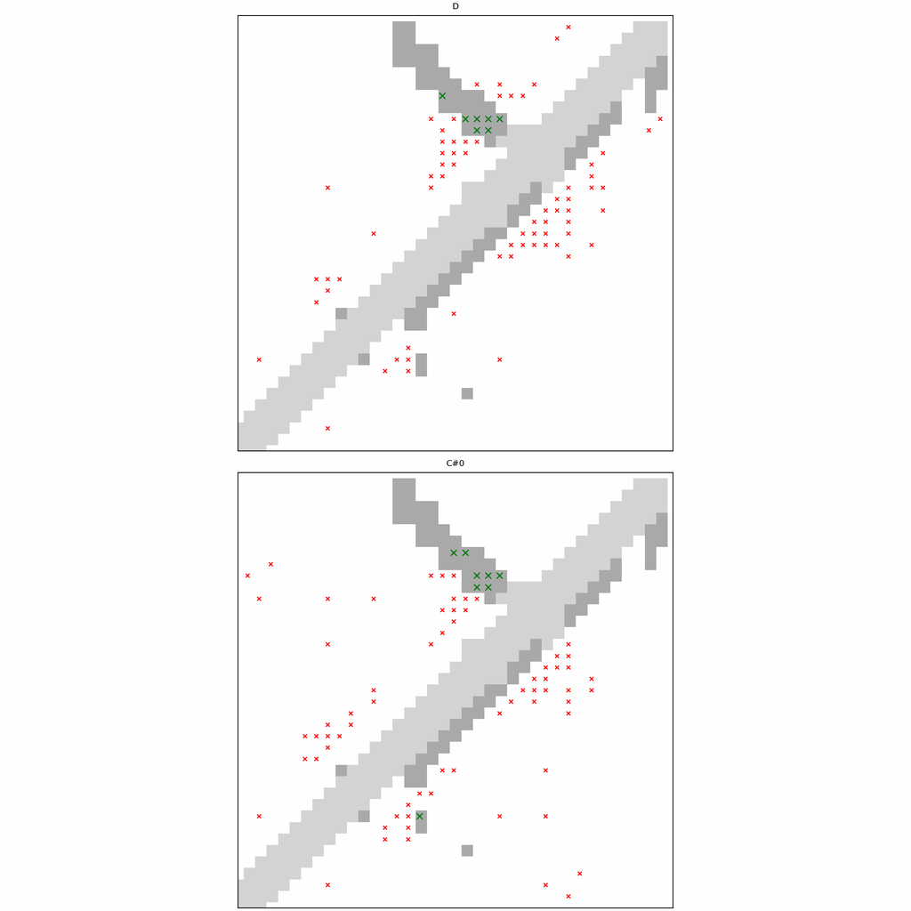

## Figure 8: Phylo null: tree with shuffled cluster fold labels.

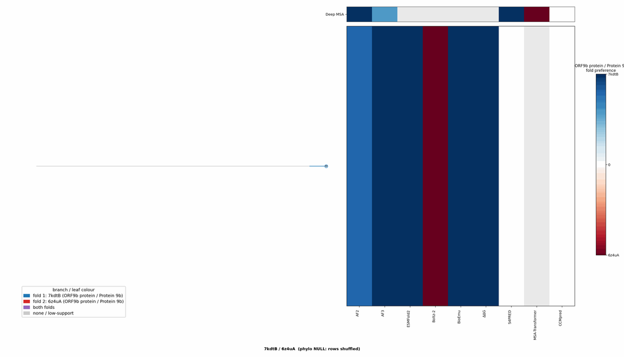

## Cluster metrics table

Per-cluster metrics underlying the figures above.

| cluster | n | neff | AF2_TM1 | AF2_TM2 | AF3_TM1 | AF3_TM2 | RE-MSAT-COM | RE-MSAT1 | RE-MSAT2 | ESM_SEQIDS | ESM_TM1 | ESM_TM2 | ΔΔG_Bias | ΔΔG_Bias_std | ΔΔG_frac_F1 | Boltz2_pref | S4PRED_pref | CCMpred_pref | BioEmu_pref |
| --- | --- | --- | --- | --- | --- | --- | --- | --- | --- | --- | --- | --- | --- | --- | --- | --- | --- | --- | --- |
| Deep | - | - | 0.42 | 0.25 | 0.4 | 0.28 | 0.0 | 0.0 | 0.01 | 6z4uA; 6z4uA; 7kdtB; 7kdtB | 0.36 ± 0.01 | 0.20 ± 0.03 | - | - | - | - | 0.23 | 0.0 | - |
| 000 | 13.0 | 4.0 | 0.41 | 0.27 | 0.44 | 0.23 | 0.0 | 0.0 | 0.01 | - | - | - | 0.97 | 6.19 | 0.3 | 0.02 | 0.23 | 0.0 | 0.09 |